# Smoking prevalence projection for Birmingham

Author

Chung Au-Yeung

Published

13 Oct 2026

## 1 Introduction

Birmingham Public Health has expanded community stop smoking services through the Smokefree Generation grant, marking a major step forward in the national journey towards becoming smokefree by 2030. The initiative expands capacity for cessation services in communities where smoking prevalence remains high and introduces targeted interventions for groups disproportionately affected by tobacco use—particularly those experiencing mental illness, substance use, or homelessness.

While these initiatives strengthen local cessation capacity, reducing smoking prevalence across all communities requires sustained monitoring. This report aims at developing a model to project the smoking prevalence in Birmingham till 2047, allowing the local team to track progress toward the 2030 target. The model will also allow scenario testing to assess the potential impact of future policies or interventions.

## 2 Method

### 2.1 Data

This projection draws upon publicly available data from multiple reputable sources. Population and migration estimates for Birmingham up to 2047 were obtained from the Office for National Statistics (ONS) 2022-based subnational population projections [1]. Smoking prevalence data were collated from several national datasets, including Adult Smoking Habits in England (ONS) [2], Smoking, Drinking and Drug Use among Young People in England 2023 (NHS Digital) [3], and the Profile of 16–17-year-old Smokers from Action on Smoking and Health (ASH) [4].

The projection has updated with the following data. Population and migration estimates for Birmingham up to 2047 were obtained from the Office for National Statistics (ONS) using 2022-based subnational population projections. [1]. Adult Smoking Habits in England (ONS) [5].

In each simulation cycle, a new cohort of 13-year-olds is introduced as non-smokers. As smoking prevalence at this age is negligible, therefore, the model assumes no 13-year-olds smoke. The injection of new cohort of 13-year-olds for each simulation cycle is obtained from ONS subnational projection [1].

In each cycle, individuals can die from any states. The all-cause mortality rates were derived from the national life tables 2021-2023 [6] and subsequently averaged across the three smoking status groups: non-smokers, current smokers, and ex-smokers. This analysis uses the equation from a prior study to calculate the death risk for non-smoker [7], as shown below:

$$P_{d0} = \frac{P_{d\text{all}}}{P_{r\text{non}} + P_{r\text{cur}} \times R_{\text{cur}} + P_{r\text{ex}} \times R_{\text{ex}}}$$

$P_{d\text{all}}$ is the all cause mortality rate while $P_{d\text{rnon}}$, $P_{d\text{rcur}}$ and $P_{d\text{rex}}$ are prevalence of non-smoker, current smoker and ex-smoker respectively. The mortality rate for current smoker are elevated by the relative risk $R_{d\text{cur}}$ and therefore, the rate is $P_{d0} \times R_{\text{cur}}$. Correspondingly, the mortality rate for ex-smoker will be $P_{d0} \times R_{\text{ex}}$. The relative risks of death for current and ex-smokers were obtained from published literature [8]. As relative risk vary according to duration since quitting (e.g., short-term vs. long-term cessation) and age at quitting, there will have different combinations of relative risks. However, the model used in this analysis does not account for age at cessation or distinguish between short- and long-term quitters. Therefore, the relative risk for ex-smokers was based on estimates corresponding to long-term quitters. Furthermore, the model includes 10 sub-states for ex-smokers, corresponding to the number of years since quitting. These sub-states allow ex-smokers to experience a diminishing probability of relapse over time, reflecting evidence that the likelihood of returning to smoking decreases with the duration of abstinence.

The transition probabilities among states in the Markov model were specific to age and gender. These probabilities were obtained an estimation produced from cross-sectional survey by the University of Sheffield [9]. The original probabilities were reported by Index of Multiple Deprivation (IMD) quintile. In order to generate an overall estimate representative of Birmingham, a weighted average was calculated using the population distribution of smokers across IMD deciles within the city. Since smoking overall has being following a downward trend in recent years and this pattern is expected to persist, it is possible that the smoking prevalence could plateau or even increase, similar to trend being observed in Australia and US. Therefore, this analysis follows the Department of Health & Social Care (DHSC)’s method [10] to fix the transition probabilities at 2022 estimate through out the simulation (The updated projection used probabilities at 2024 estimate). With regards to DHSC’s method again, a long-term quit probability was applied to ex-smokers who had remained abstinent for 10 years, allowing them to transition to the non-smoker state. This implies that a proportion of ex-smokers will share the same health risk as the non-smokers.

In order to follow the DHSC’s method as closely as possible, instigation rates for 13- to 15-year-olds were calculated using a scaling approach. This was carried out by referencing the instigation rates for males and females from the US SimSmoke model [11], applying the assumption that the ratio between adjacent age groups in the US model also applies to the Birmingham population.

### 2.2 Model structure

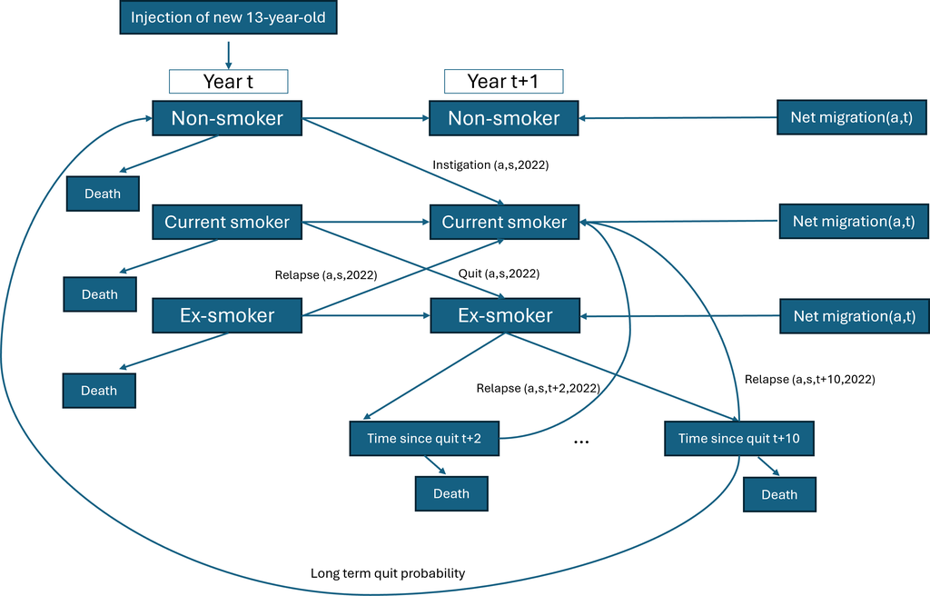

**Figure 1.** Markov state transition diagram for smoking prevalence

Figure 1 shows that at the beginning of each year t, the population is divided into three main states: non-smokers, current smokers, and ex-smokers.

- **Non-smokers:** At year *t+1*, the number of non-smokers equals to (1) the number of people who were non-smokers in year *t* and remained non-smokers, plus (2) the number of ex-smokers who reached 10 years since quitting in year *t* and transitioned back to the non-smoker state, minus (3) the number of non-smokers in year *t* who started smoking and moved to the smoker state in year *t+1*, minus (4) the number of non-smokers in year *t* who died, plus (5) the net number of non-smokers migrating into Birmingham (in-migrants minus out-migrants) during year *t*.
- **Current smokers:** At year *t*+1, the number of current smokers equals (1) those who were smokers in year t and continued smoking, plus (2) non-smokers in year t who started smoking in year *t*+1, plus (3) ex-smokers in year *t* who relapsed and returned to smoking, minus (4) smokers in year *t* who quit and moved to the ex-smoker state, minus (5) smokers in year *t* who died, plus (6) the net number of smokers migrating into Birmingham during year *t*.
- **Ex-smokers:** At year *t*+1, the number of ex-smokers equals (1) those who were ex-smokers in year *t* and remained ex-smokers, plus (2) smokers in year *t* who quit during the year and became new ex-smokers, plus (3) every former smoker who quit between year *t–10* and *t* and continues to remain smoke-free (i.e., those progressing through the “time since quit” categories up to 10 years), minus (4) ex-smokers in any “time since quit” category who relapsed and returned to smoking, minus (5) ex-smokers in any “time since quit” category who died during year *t*, minus (6) ex-smokers in year *t* who reached 10 years since quitting and transitioned back to the non-smoker state, plus (7) the net number of ex-smokers migrating into the area during year *t*.

At the end of each cycle, every person ages by one year (i.e., age *a* becomes *a+1* in year *t+1*), and in each new year *t+1*, a new cohort of 13-year-olds enters the model as non-smokers. Every person is given a new set of age and gender specific transition probabilities when cycle moves forward. For example, a 17-year-old male in year t will be assigned the transition probabilities corresponding to 17-year-old males; when he becomes 18 in the next cycle (*t*+1), his probabilities are updated to those specific to 18-year-old males. This ensures that changes in smoking behaviour reflect age- and gender-related differences in initiation, quitting, relapse, and mortality rates over time.

### 2.3 How scenario works?

To model each policy scenario, assumptions of reduction in instigation rate were applied at 10%, 30%, 60% and 90%. It has to be noted that the reduction in instigation is year-by-year, meaning that reduction will get compounded over time, implying that the implementation of the policy does not provide a one-off change but the effect becomes progressively more effective. For example, under a 10% annual reduction scenario, the instigation rate in year *t* would be multiplied by 0.9. In the following year (*t+1*), the rate would be further multiplied by 0.9², and so on, leading to a cumulative reduction effect over time.

## 3 Results

### 3.1 Baseline result

Applying the baseline transition probabilities to the initial population produces the baseline scenario, representing outcomes in the absence of any policy intervention. The first cycle of the model in 2024 shows that smoking prevalence among 14 to 30 year olds is 9.01%. Without any additional policies being implemented, smoking prevalence in Birmingham is estimated to reach 10.21% in 2047.

From the latest data, the first cycle of the model in 2025 shows the the smoking prevalence for those among 14 to 30 year old is 7.71%. Without any additional policies being implemented, the smoking prevalence in Birmingham is estimated to reach 9.9% in 2047.

Unlike the published DHSC model, where prevalence declines over time, our baseline increases slightly before levelling off. This is mainly due to how the model works. In the first cycle, every age group starts at the observed survey prevalence. Over time, these people age out of the 14 to 30 age group and are replaced by those who entered the model at age 13, whose smoking status depends only on the initiation, quit and relapse probabilities. These probabilities come from a different data source to the initial prevalence, and they imply a slightly higher prevalence among young people than was observed. As a result, prevalence gradually drifts upwards until all of the original cohorts have aged out of the age group, after which it stays broadly stable.

In addition, the transition probabilities in this model were calculated as a weighted average by deprivation quintile. Given that Birmingham is one of the most deprived local authorities, the quit rate is lower and the relapse rate is higher than the national average. Consequently, fewer individuals quit and more transition back from ex-smoker to current smoker, which adds to the small increase. The transition probabilities are also held constant at their base-year values, so the model does not assume any continuing decline in smoking uptake, unlike the DHSC projections. The baseline should therefore be read as a reference point for comparing policy scenarios rather than as a forecast of rising smoking in Birmingham.

Moreover, this analysis employed an open-cohort markov model, meaning that migration was incorporated, whereas the DHSC model was based on a closed cohort. This might help explain why the smoking prevalence among younger population might have increased slightly.

[interactive chart not shown]

The baseline result for adults (18+) is comparable to the projections produced by Cancer Research UK [12]. Using the 2024 data, the model estimates that smoking prevalence among adults is 10% in 2025. Without any additional policies being implemented, smoking prevalence in Birmingham is estimated to fall to 5.5% in 2047.

Unlike the 14 to 30 age group, adult prevalence declines steadily over time. This is because older age groups, which have higher smoking prevalence, are gradually replaced by younger cohorts with lower prevalence, and more smokers quit as they age. The trend follows a similar pattern to Cancer Research UK’s projections, although their model shows a faster decline. This is likely due to the same reasons discussed above: the transition probabilities in this model are weighted towards Birmingham’s more deprived population, with lower quit and higher relapse rates, and they are held constant at base-year values rather than assuming a continuing decline in smoking uptake.

[interactive chart not shown]

### 3.2 Scenario

This analysis followed the scenario where the Tobacoo and Vape bill [13] that has passed the second reading in House of Lords will be successfully implemented in the proposed date on the 1st of January 2027 [14]. The bill aims to prohibit the sale of tobacco to people born on or after 1 January 2009 and provision about the licensing of retail sales and the registration of retailers, alongside enforcement measures and financial penalties for non-compliance. While some public debate has characterised the policy as a form of “nanny state” intervention, the Bill represents one of the most ambitious tobacco control measures in recent UK history, aiming to protect future generations from nicotine addiction and related harms.

Therefore, this analysis introduces the Tobacco and Vapes Bill within the 2027 model cycle, assuming that individuals turning 18 in 2027 will be the first cohort affected by the policy. The model applies a year-on-year reduction in instigation rates, meaning the effect compounds over time as younger cohorts progressively enter the population under the new legislation. However, as there is currently no empirical evidence quantifying the potential impact of the Bill, the effect must be modelled through assumptions. Accordingly, Scenarios 1–4 represent varying levels of reduction in smoking instigation rates, modelled as 10%, 30%, 60%, and 90% decreases, respectively, relative to the baseline scenario of no policy intervention.

The results of 2024 data show that for those among 14 to 30 years old, smoking prevalence is projected to decline to 3.82% by 2047 under Scenario 1 (10% reduction in instigation rate), while Scenario 2 (30% reduction) reaches 1.93% in the same year. Scenarios 3 and 4, representing larger reductions of 60% and 90%, produced almost identical trends, with prevalence stabilising at 1.85% by 2047.

The latest results of 2025 data show that for those among 14 to 30 years old, smoking prevalence is projected to decline to 3.73% by 2047 under Scenario 1 (10% reduction in instigation rate), while Scenario 2 (30% reduction) reaches 1.91% in the same year. Scenarios 3 and 4, representing larger reductions of 60% and 90%, produced almost identical trends, with prevalence stabilising at 1.84% by 2047.

[interactive chart not shown]

The results for 2025 data show that for adults (18+), smoking prevalence is projected to decline to 3.03% by 2047 under Scenario 1 (10% reduction in instigation rate), while Scenario 2 (30% reduction) reaches 2.13% in the same year. Scenarios 3 and 4, representing larger reductions of 60% and 90%, produced almost identical trends, with prevalence stabilising at approximately 1.9% by 2047.

The results for 2024 data show that for adults (18+), smoking prevalence is projected to decline to 3.31% by 2047 under Scenario 1 (10% reduction in instigation rate), while Scenario 2 (30% reduction) reaches 2.39% in the same year. Scenarios 3 and 4, representing larger reductions of 60% and 90%, produced almost identical trends, with prevalence stabilising at approximately 2.1% by 2047.

[interactive chart not shown]

## 4 Limitation

In developing the model, several assumptions and simplifications were necessary, and as such, the findings should be interpreted in light of these limitations.

## References

[1]

Office for National Statistics. [Subnational population projections for england: 2022‑based](https://www.ons.gov.uk/peoplepopulationandcommunity/populationandmigration/populationprojections/bulletins/subnationalpopulationprojectionsforengland/2022based). Office for National Statistics, UK; 2025.

[2]

Office for National Statistics. [Adult smoking habits in the UK: 2022](https://www.ons.gov.uk/peoplepopulationandcommunity/healthandsocialcare/healthandlifeexpectancies/bulletins/adultsmokinghabitsingreatbritain/2022). Office for National Statistics, UK; 2023.

[3]

NHS Digital. [Smoking, drinking and drug use among young people in england, 2023](https://digital.nhs.uk/data-and-information/publications/statistical/smoking-drinking-and-drug-use-among-young-people-in-england/2023). NHS Digital; 2023.

[4]

Action on Smoking and Health (ASH). [Profile of 16/17‑year‑old smokers](https://ash.org.uk/uploads/Profile-of-16-and-17-year-old-smokers.pdf). ASH; 2021.

[5]

Office for National Statistics. [Adult smoking habits in the UK: 2024](https://www.ons.gov.uk/peoplepopulationandcommunity/healthandsocialcare/healthandlifeexpectancies/bulletins/adultsmokinghabitsingreatbritain/2025). Office for National Statistics, UK; 2026.

[6]

Office for National Statistics. [National life tables, UK: 2021 to 2023 (additional data)](https://www.ons.gov.uk/peoplepopulationandcommunity/birthsdeathsandmarriages/lifeexpectancies/bulletins/nationallifetablesunitedkingdom/2021to2023additionaldata). Office for National Statistics; 2024.

[7]

Song F, Elwell-Sutton T, Naughton F, Gentry S. Future smoking prevalence by socioeconomic status in england: A computational modelling study. Tobacco Control 2021;30:380–5. https://doi.org/10.1136/tobaccocontrol-2019-055490.

[8]

Jeon J, Inoue-Choi M, Mok Y, McNeel TS, Tam J, Freedman ND, et al. Mortality relative risks by smoking, race/ethnicity, and education. American Journal of Preventive Medicine 2023;64:S53–62. https://doi.org/https://doi.org/10.1016/j.amepre.2022.12.006.

[9]

Gillespie D, Webster L, Leeming G, Opazo-Breton M, Brennan A. [Smktrans: An r package for estimating smoking state transition probabilities](https://stapm.gitlab.io/smoking_state_transitions.html) 2023.

[10]

Department of Health and Social Care. [Modelling for the smokefree generation policy](https://www.gov.uk/government/publications/smokefree-generation-policy-modelling-report/modelling-for-the-smokefree-generation-policy). UK Government; 2023.

[11]

Cancer Intervention and Surveillance Modeling Network (CISNET). [Smoking history generator (SHG) and individual outcome model resources](https://resources.cisnet.cancer.gov/projects/#shg/iomr/resources) 2024.

[12]

Cancer Research UK. [Smoking prevalence projections for england](https://www.cancerresearchuk.org/sites/default/files/cancer_research_uk_smoking_prevalence_projections_england_0.pdf). Cancer Research UK; 2021.

[13]

UK Parliament. [Tobacco and vapes bill](https://bills.parliament.uk/bills/3879) 2024.

[14]

Department of Health and Social Care. [Tobacco and vapes bill: Creating a smoke-free UK and tackling youth vaping](https://www.gov.uk/government/publications/the-tobacco-and-vapes-bill-creating-a-smoke-free-uk-and-tackling-youth-vaping/tobacco-and-vapes-bill-creating-a-smoke-free-uk-and-tackling-youth-vaping) 2024.